# Weekly Prep 10 Replication

## Introduction

This is the replication file for Week 10’s Weekly Prep.

## Dependencies

This file uses the `ggplot2` package for plotting and data:

```r
library(ggplot2)
```

## Load Data

We’ll assign the `mpg` data from `ggplot2` to a data frame object named `autoData`:

```r
autoData <- mpg
```

## Questions

### Question 1

The following code replicates the scatterplot show in Section 3.2.2 of R for Data Science:

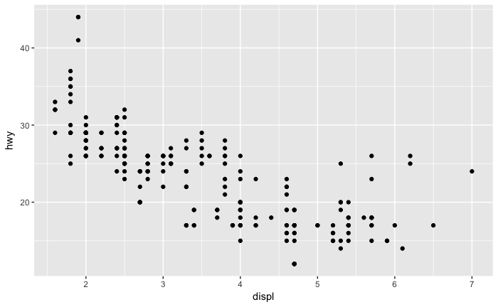

```r
ggplot(data = autoData) +
  geom_point(mapping = aes(x = displ, y = hwy))
```

This plot shows that, as engine displacement increases along the x axis, the corresponding values for each observation’s highway fuel efficiency decrease on the y axis.

#### Saving Plots

Since you’ll want to include plots in your draft presentation, I want to show you quickly how to save them. The `ggsave()` function is used for this purpose. You can specify the file name *and* extension in double quotes, and provide some additional parameters like the height, width, and dots-per-inch of the resulting file. I’ve set this output up so that it creates a plot that is 800 points (282 mm) by 600 points (211 mm) at 500 dpi. This is a good approximate size for presentations, though you’ll have to tweak the settings for your own slides.

```r
ggsave("week-10-prep-fig1.png", width = 282, height = 211, units = "mm", dpi = 500)
```

### Question 2

The following code creates a scatterplot of the variables `hwy` and `cyl`:

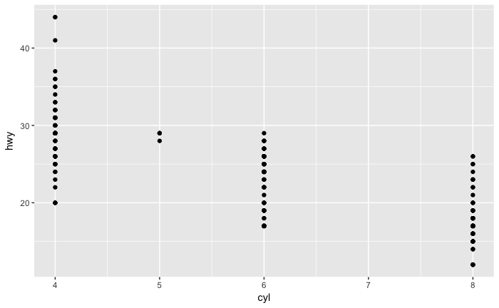

```r
ggplot(data = autoData) +
  geom_point(mapping = aes(x = cyl, y = hwy))
```

This looks a bit awkward because `cyl` has a discrete number of values. You can see the variations in highway fuel efficiency do generally decrease as the number of engine cylinders in a car increases along the x axis.

### Question 3

The following code creates a scatterplot of the variables `class` and `drv`:

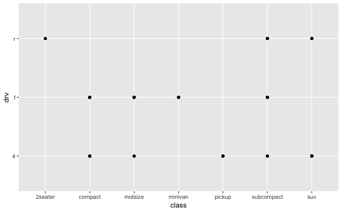

```r
ggplot(data = autoData) +
  geom_point(mapping = aes(x = class, y = drv))
```

The plot is not useful because both variables are discrete, so we end up with only a small number of possible combinations where all of the x and y values are the same, so the points layer on top of each other. Scatterplots are best for comparing continuous variables.